# Rapport

Guide utilisateur pour l’application R Shiny : Installation et utilisation

Author

OUALLA Khadija

# 1. Application R Shiny

### Objectif de l’Application

Le “Tableau de bord EDA” est une application R Shiny conçue pour offrir une plateforme interactive pour l’analyse exploratoire de données. Elle permet aux utilisateurs de charger, visualiser, analyser et appliquer des techniques de machine learning sur des ensembles de données.

### Conception de l’Application

#### Interface Utilisateur (UI)

- **`dashboardPage`** : Utilise `shinydashboard` pour une organisation modulaire de l’interface, comprenant `dashboardHeader`, `dashboardSidebar`, et `dashboardBody`.
- **En-tête** (`dashboardHeader`) : Affiche le titre de l’application.
- **Sidebar** (`dashboardSidebar`) : Intègre un menu de navigation avec des options pour le chargement de données, les résumés statistiques, la visualisation et les techniques de machine learning.
- **Corps Principal** (`dashboardBody`) : Contient les onglets correspondant aux différentes sections de l’application.

#### Boutons et Entrées

- **`fileInput`** : Permet le téléchargement de fichiers CSV.
- **`selectInput`** et **`actionButton`** : Facilitent la sélection de variables et le déclenchement d’actions comme le calcul des statistiques ou la construction de modèles de machine learning.

### Logique Serveur et Traitement des Données

#### Gestion des Données

- **Chargement et Affichage des Données** : Utilisation de `reactive` pour la gestion des données chargées et affichage via `renderReactable`.
- **Calcul des Statistiques** : `renderTable` affiche des statistiques descriptives basées sur la sélection de l’utilisateur.
- **Visualisation des Données** : `renderPlot` et `ggplot2` sont utilisés pour créer des graphiques personnalisés.

### Fonctionnalités de Machine Learning

##### Arbre de Décision

- **Construction et Visualisation** : Utilisation de `rpart` pour construire des arbres de décision et `rpart.plot` pour leur visualisation.

##### K-Nearest Neighbors (KNN)

- **Préparation et Exécution** : Normalisation des données, division en ensembles d’entraînement et de test, et application de l’algorithme KNN via le package `class`.
- **Visualisation des Résultats** : Présentation des résultats de KNN en utilisant `ggplot2`.

### Démarche et Interactivité

##### Boutons et Actions

- Chaque bouton déclenche une action spécifique dans le serveur, géré par `observeEvent` ou `eventReactive`.

##### Flux de Travail de l’Application

- **Chargement des Données** → **Exploration et Visualisation** → **Application de Machine Learning**

##### Personnalisation Visuelle

- **CSS** : Utilisation de `styles.css` pour personnaliser les couleurs et le style des éléments de l’interface.

### Utilisation de l’Application

###### Étape 1 : Chargement des Données

- Accédez à l’onglet **“Charger Données”**.
- Utilisez le bouton **“Choisissez le fichier CSV”** pour télécharger votre jeu de données.
- Sélectionnez le nombre de lignes à afficher dans le tableau de données.

###### Étape 2 : Exploration des Données

- Naviguez vers l’onglet **“Résumé Statistique”**.
- Choisissez une variable dans le menu déroulant pour voir ses statistiques descriptives.
- Cliquez sur **“Calculer”** pour afficher le résumé statistique.

###### Étape 3 : Visualisation des Données

- Allez à l’onglet **“Visualisation”**.
- Sélectionnez le type de graphique (Histogramme, Boîte à moustaches, Diagramme en bâtons).
- Choisissez la variable à visualiser.
- Le graphique correspondant sera affiché à l’écran.

###### Étape 4 : Application de Machine Learning

- Pour l’**Arbre de Décision** :
  - Rendez-vous dans le sous-menu **“Arbre de Décision”** sous l’onglet **“Machine Learning”**.
  - Sélectionnez la variable cible et les variables prédictives.
  - Cliquez sur **“Construire l’Arbre de Décision”** pour visualiser l’arbre.
- Pour **KNN (K-Nearest Neighbors)** :
  - Accédez à **“KNN”** sous l’onglet **“Machine Learning”**.
  - Définissez la variable cible, les variables prédictives, et le nombre de voisins (k).
  - Cliquez sur **“Exécuter KNN”** pour voir les résultats de l’analyse KNN.

### Conseils d’Utilisation

- Assurez-vous que vos données sont correctement formatées et nettoyées avant de les charger dans l’application.
- Explorez différentes visualisations pour mieux comprendre vos données.
- Expérimentez avec différents paramètres dans les modèles de machine learning pour voir comment ils affectent les résultats.

Pour illustrer l’interface utilisateur et les fonctionnalités de l’application, voici une capture d’écran du “Tableau de bord EDA” en action :

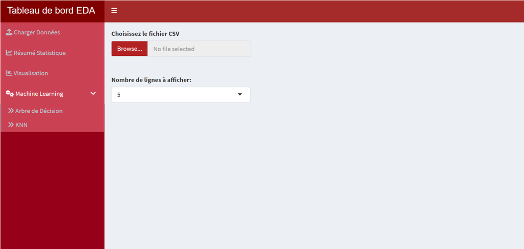

L’application Tableau de bord EDA

### Réflexions sur le Développement

Ce projet a permis de développer des compétences en programmation R, en particulier dans l’utilisation de Shiny, ggplot2, et dans l’intégration de méthodes statistiques et de machine learning.

# 2. Package R

### Contexte

Création et Utilisation du Package R pour l’Application Shiny : Dans le but d’améliorer l’accessibilité et la facilité d’utilisation de l’application “Tableau de bord EDA”, le projet a été étendu pour inclure la création d’un package R. Cette initiative a été guidée par des ressources en ligne, notamment le tutoriel disponible sur [INRAE](https://inter_cati_omics.pages.mia.inra.fr/hackathon_shiny_2020/3_deploiement/2_creation_package_R_de_son_application/), qui a fourni des instructions détaillées sur le déploiement d’applications Shiny en tant que packages R.

### Processus de Création du Package

Le package a été développé pour encapsuler l’application Shiny, simplifiant ainsi le processus d’installation et d’exécution pour l’utilisateur final. Ce processus a inclus la structuration du code de l’application, la définition des dépendances, et la préparation du package pour la distribution.

### Instructions pour l’Installation et le Lancement

Pour installer et lancer l’application “Tableau de bord EDA” à partir du package R, veuillez suivre les étapes suivantes :

Avant de lancer l’application Shiny, il faut exécuter cette commande pour installer les bibliothèques nécessaires :

```r
# Liste des packages requis
packages <- c("shiny", "e1071", "class", "ggplot2", "viridis", "rpart",
              "rpart.plot", "shinydashboard", "reactable", "shinythemes", "shinyjs")

# Fonction pour installer et charger les packages
install_and_load_packages <- function(packages) {
  for (pkg in packages) {
    if (!require(pkg, character.only = TRUE)) {
      install.packages(pkg)
      library(pkg, character.only = TRUE)
    }
  }
}

# Appeler la fonction pour les packages requis
install_and_load_packages(packages)
```

1. **Installation du Package** : Ouvrez R et exécutez la commande suivante pour installer le package :

```r
   install.packages("https://github.com/OUALLAK/ShinyExec/raw/main/ShinyApp_0.1.0.tar.gz",
   repos = NULL, type = "source")
```

2. **Chargement du Package** : Une fois l’installation terminée, chargez le package en utilisant :

```r
library("ShinyApp")
```

3. **Lancement de l’Application** : Pour démarrer l’application Shiny, exécutez :

```r
shiny_application()
```

L’application s’ouvrira alors dans votre navigateur web par défaut.